# Data Management, day 3

Joe and Arsenio  
2019-07-11

### To be covered today...

- (Continuation of statistical analysis)
- (Continuation of data sharing)
- Data requirements, standards, specification
- Managing data quality and validation
- Study registration
- Information in the protocol
- Statistics and Statiscal analysis plan (SAP)

### Statistical analysis, review of concepts (code)

- Libraries
- The verbs
- Dataset and variable notation
- Plots

### Statistical analysis, review of concepts (code)

- Libraries
  - `tidyverse` and `maps`
- The verbs
  - `arrange`
  - `select`
  - `filter`
  - `mutate`
  - `summarise`
  - `group_by`
- Dataset and variable notation
- Plots

### Continuation of data sharing

- Raw data
  - Aka “source” data
  - Most trials never require sharing it; some benefit from it, but must be done in a way that is safe, legal, etc.
- Analyzable data
  - “Derived” variables
  - Anonymized identifiers
  - Some unnecessary info

### Continuation of data sharing

- Raw data
  - Aka “source” data
  - Most trials never require sharing it; some benefit from it, but must be done in a way that is safe, legal, etc.
- Analyzable data
  - “Derived” variables
  - Anonymized identifiers
  - Some unnecessary info

### Continuation of data sharing

- Summary data
  - Aggregated data
- Metadata
  - Protocol, DMP, manual of operations, details on study execution, SAP
- Analytical code
  - Always share!

### Continuation of data sharing

- As of last year, ICMJE journals require a “data sharing statement”, including:
  - Will individual-level data be available
  - What other documents will be shared (protocol, analysis plan, analytical code, etc.)
  - When will data be available?
  - With whom?
  - What types of analyses, what types of restrictions?
  - By what mechanism?

### Data requirements, data specification

## What are clinical trial “study data”?

### Data requirements, standards, specification

## What are clinical trial “study data”?

- Clinical study data are information about a person in a clinical trial.
- Study data include demographic information, details of medical treatment, descriptions of the participant’s progress, and other relevant information.
- In early studies, this same information is captured for animals and is called nonclinical study data. (FDA)

### Data requirements, standards, specification

## What are data “standards”?

### Data requirements, standards, specification

## What are data “standards”?

- General framework for homogeneizing processes, and data products.
- But there are also some concepts that are specific to data management for clinical research.
- The FDA has a guide which is useful, even if youre trial is not related to the FDA: https://www.fda.gov/media/122913/download

### Data requirements, standards, specification

## Some specific standards

- XML (extensible mark-up language) for metadata
- PDF (portable document format) for human-readable metadata
- Raw data: open-source whenever possible!
- Dataset size: <5 gb
- Variables:
  - Column width: <= 18
  - Variable name: 8
  - Variable descriptive label: 40
- Encoding:
  - ASCII
  - UTF-8 only if necessary

### Types of data (from the regulatory perspective)

- Subject identifier
- Unique subject identifier
- Adjudication data
- Supplemental qualifier data
- Demographics
- Adverse events
- Laboratory
- Analysis data
- Core variables

### Types of data (from the regulatory perspective) (continued)

- Efficacy variables
- Safety variables
- Timing variables
- Imputed data

### Other types of potentially relevant documents

- CRF
- aCRF (annotated case report form)
  - a PDF document that maps the clinical data collection fields used to capture subject data (electronic or paper) to the corresponding variables or discrete variable values contained within the SDTM datasets
- Therapeutic area guides (Malaria, HIV, Vaccines, etc.)

### Organizing all the data, metadata, code, etc...

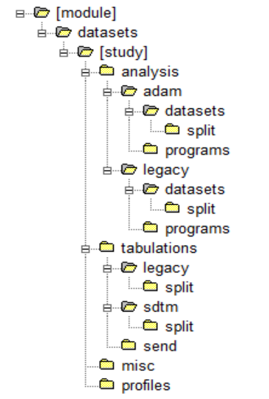

### Organizing all the data, metadata, code, etc...

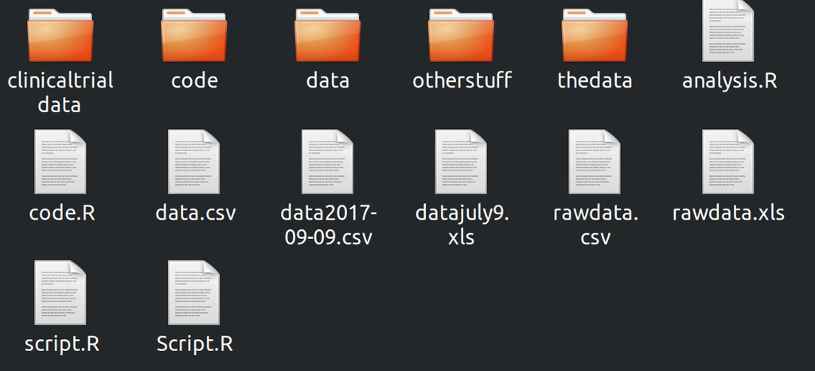

### Overall principles of standards

- Reproducibility, replicability
- Bi-direction traceability
- Documentation
- Clarity
- Auditability

### Managing data quality and validation

- There is a lack of evidence that “monitoring” actually improves quality (https://www.ncbi.nlm.nih.gov/pmc/articles/PMC5801732/)
- “Risk-adapted” procedures, therefore, are preferred
- These are usually understood to be during or after processing
- But there are pre-processing procedures too…

### Managing data quality and validation

## What is “risk-based quality management”?

the identification of the risks on a continuous basis for all risk-bearing activities throughout the design, conduct and evaluation of clinical trials based on existing and ongoing generated or emerging information about the investigational medicinal product(s) and the sponsor’s and collaborators’ systems and organisation. Identification of low risks can also be important as there is potential for adaptation to conventional practice in the management of the trial.

### Managing data quality and validation

## What is entailed by risk-based management?

- Quality tolerance limits
- Ongoing monitoring
- Alerts, logs, deviation detection
- Automation of reporting
- Prioritization

### Managing data quality and validation

## Procedures for minimizing risk prior to collecting data

- Design leaner protocols that minimize unnecessary data collection.
- Define the data quality strategy, and data governance. Develop an implementation plan.
- Assign the roles and responsibilities for data governance.
- Develop policies, data quality metrics, ongoing monitoring and reporting through existing tech.
- Use data quality tools and technology to monitor the trends.
- Build data standards program applicable for all clinical trials and apply standard metrics.

### Study registration

## Why register

(Discussion)

## Do you have to register?

- You probably have to register trial methodology (most places).
- You may have to register study results (FDA).
- Registration with
  - WHO (https://www.who.int/ictrp/trial_reg/en/)
  - FDA (https://clinicaltrials.gov/ct2/manage-recs/how-register)
  - EU (https://www.clinicaltrialsregister.eu/)
  - Africa (http://www.edctp.org/pan-african-clinical-trials-registry/)

https://www.ncbi.nlm.nih.gov/pmc/articles/PMC3877534/

### Information in the protocol

(Discussion first)

### Information required in the protocol

- Data collection and management responsibilities
- Study records retention
- Protocol deviations
- Publication and data sharing policy

### Additional information in the protocol

(Discussion first)

### Additional information in the protocol

- Data collection
- CRF tracking
- CRF annotation
- Database design
- Data entry
- Coding
- Data validation
- Discrepancy management
- Database lock
- Software
- Contingency plans
- Backups
- Security, authorization, access
- Data publication plans
- Interim analyses

### Statistical analysis plan (SAP)

## What is the SAP?

- A guide for YOU to help you in your work
- A piece of evidence to the world that
  - You are not on a “fishing expedition”
  - Your methods are transparent
  - Your result are reliable

### Statistical analysis plan (SAP)

## When, and by whom, does a SAP get prepared?

(Discussion)

### Statistical analysis plan (SAP)

## What is included in a SAP?

### Conceptual

- Study design
- Justification for study design
- Outcomes and endpoints -Primary -Secondary
- Population(s) and subgroups to be analyzed
- Analyses (for each outcome)
- Handling of missingness, contingencies, unexpected events
- Secondary/downstream analyses

### Statistical analysis plan (SAP)

## What is included in a SAP?

### Technical

- DMP (in some cases)
- Roles and responsibilities
- Internal quality assurance
- Code transparency
- Sample size, power, interim analyses
- Assumed confounders (and justification)
- Software, packages, integrations

### Statistical analysis plan (SAP)

## Detailed outline

- Study title that matches the study protocol
- Trial registration number
- SAP version number with dates
- Version of protocol referenced
- SAP revision history
- Reason for each SAP revision
- Timing of SAP revisions relative to interim analyses

### Statistical analysis plan (SAP)

## Detailed outline

- SAP contributors with roles and responsibilities
- Person writing SAP
- Senior statistician
- Principal investigator
- Background and rationale of study
- Objectives and hypotheses
- Study type

### Statistical analysis plan (SAP)

## Detailed outline

- Randomization details
- Sample size calculation, if applicable
- Superiority, equivalence, or noninferiority hypothesis testing framework.
- Interim analysis, timing of analysis, and person performing interim - analysis, if applicable
- Adjustment of the significance level due to interim analysis
- Guidelines for stopping study early
- Timing of final analysis

### Statistical analysis plan (SAP)

## Detailed outline

- Timing and time interval for assessing each outcome; visit windows
- Level of statistical significance (P values) and whether one‐ or two‐sided
- Plan and rationale for adjustment for multiplicity, if applicable, including how type 1 error will be controlled
- Confidence intervals to be reported and whether one‐ or two‐sided
- Definition of intervention adherence and how it will be presented
- Definition and summary of protocol deviations
- Definition of population being analyzed

### Statistical analysis plan (SAP)

## Detailed outline

- Reporting of screening data to describe representation of study population, if applicable
- Inclusion and exclusion criteria
- Recruitment strategy
- Level and timing of withdrawal
- Presentation of withdrawal and follow‐up data
- Baseline patient characteristics and how they will be descriptively summarized
- Definitions of outcomes and sequence of measurement
- Specific measurements and units

### Statistical analysis plan (SAP)

## Detailed outline

- Calculations or transformations used to derive outcome
- Analysis method used
- Presentation of treatment effects
- Covariates and adjustments
- Methods to check for distributional assumptions
- Alternative methods if distributional assumptions are false
- Sensitivity analysis for each outcome if applicable

### Statistical analysis plan (SAP)

## Detailed outline

- Subgroup definition and analysis, if applicable
- Method for handling missing data
- Additional statistical analysis, if applicable
- Details on summarizing safety data
- Statistical packages used for analysis
- Reference to standard operating procedure or additional documents